# CRIM 595 City Development

Kyle Weber

19 July 2023

# PACKAGES

```r
library(googlesheets4)
gs4_deauth()
library(tidyverse)
library(leaflet)
library(sf)
library(tigris)
```

## Acquire Data

```r
default.crs = sf::st_crs(4326)
fairfax.roads <- roads("VA", "Fairfax city")
fairfax.county <- county_subdivisions("VA", "Fairfax city")
city.dev <- read_sheet('https://docs.google.com/spreadsheets/d/1bvJCJSDmoayfMljJs9ajSb4PN4waE5MKDoz9vewyax0')
```

```
## ✔ Reading from "city of fairfax development projects report".
```

```
## ✔ Range 'as of 31 March 2023'.
```

```r
city.dev$Lat <- as.numeric(city.dev$Lat)
city.dev$Lon <- as.numeric(city.dev$Lon)
pts.city <- st_as_sf(city.dev, coords = c("Lon", "Lat"), crs=default.crs)
id.calls <- "1gRoL7lZlwm7sreA5F9WbPoH5su4n4iGS"
calls.full <- read.csv(sprintf("https://docs.google.com/uc?id=%s&export=download", id.calls))
```

## Wrangle Data

```r
calls.full$date <- as.Date(calls.full$date)
calls.full$dow <- weekdays(calls.full$date)
calls.full$day <- day(calls.full$date)
calls.full$month <- substr(calls.full$date, 6, 7)
calls <- subset(calls.full, !is.na(calls.full$lat))
calls <- subset(calls, calls$date > '2021-01-01')
calls <- subset(calls, calls$type == 'TRAFFIC STOP' | calls$type == 'SUSPICIOUS' |
                  calls$type == 'BUILDING CHECK' |
                  calls$type == 'TRESPASSING')

pts.calls <- st_as_sf(calls, coords = c("lon", "lat"), crs=default.crs)
facility.mean <- as.numeric(mean(st_length(st_nearest_points(pts.city, pts.calls))))
facility.sd <- as.numeric(sd(st_length(st_nearest_points(pts.city, pts.calls))))

facility.buffer <- st_buffer(pts.city, 75)

facility.activity <- st_join(pts.calls, left = FALSE, facility.buffer["Property"])

facility.activity <- facility.activity %>% left_join(calls, by = 'ID')
facility.activity <- facility.activity[c(1:13,23)]
names(facility.activity) <- c("date", "time", "number", "type", "hour", "year", "ID",
                              "dow", "day", "month", "name", "lat", "lon", "geometry")
summary1 <- facility.activity %>%
  group_by(type) %>%
  summarise(count = n()) %>%
  mutate(PCT = round(count/sum(count)*100,2))

summary2 <- facility.activity %>%
  group_by(name, type) %>%
  summarise(count = n()) %>%
  mutate(PCT = round(count/sum(count)*100,2))
facility.activity <- subset(facility.activity,
                            facility.activity$type == 'TRAFFIC STOP' |
                              facility.activity$type == 'SUSPICIOUS' |
                              facility.activity$type == 'BUILDING CHECK' |
                              facility.activity$type == 'TRESPASSING' |
                              facility.activity$type == 'MOTOR VEHICLE CRASH')

activity.day.time <- facility.activity %>%
  group_by(dow, hour) %>%
  summarise(count = n())
```

[output not shown]

```r
activity.day.time <- subset(activity.day.time, !is.na(activity.day.time$hour))

activity.type.day.time <- facility.activity %>%
  group_by(type, dow, hour) %>%
  summarise(count = n())
activity.type.day.time <- subset(activity.type.day.time, !is.na(activity.type.day.time$hour))
```

## Visualize Data

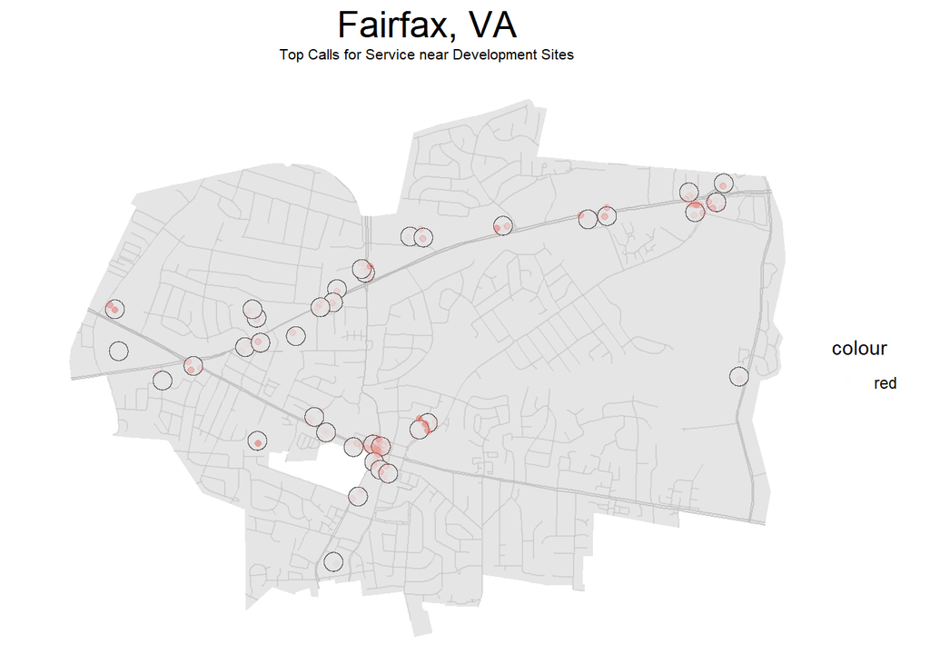

```r
##hotspot
ggplot() +
  geom_sf(data = fairfax.county, color = "white") +
  geom_sf(data = fairfax.roads, inherit.aes = FALSE, color = "grey", size = .3, alpha = .5) +
  geom_sf(data = facility.buffer) +
  geom_point(aes(x = lon, y = lat, color = "red"), data = facility.activity, alpha = 0.01, size = 1.5) +
  theme_void() +
  theme(plot.title = element_text(size = 20, hjust=.5), plot.subtitle = element_text(size = 8, hjust=.5, margin=margin(2, 0, 5, 0))) +
  labs(title = "Fairfax, VA", subtitle = "Top Calls for Service near Development Sites")
```

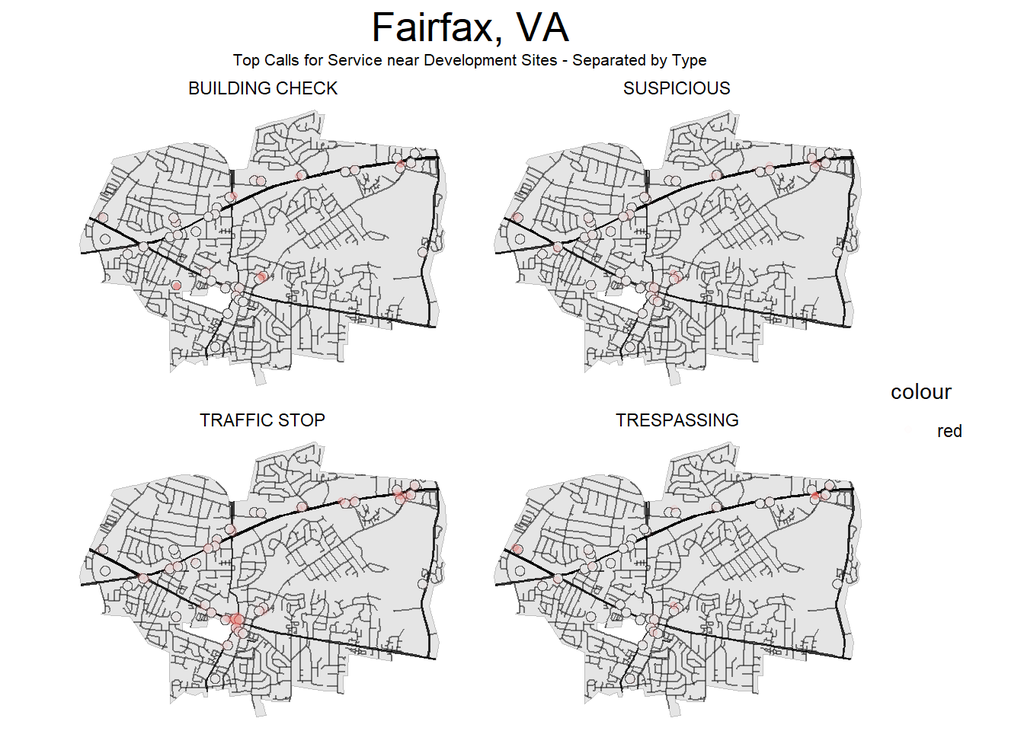

```r
ggplot() +
  geom_sf(data = fairfax.county, color = "gray") +
  geom_sf(data = fairfax.roads, inherit.aes = FALSE, color = "black", size = .3, alpha = .5) +
  geom_sf(data = facility.buffer) +
  geom_point(aes(x = lon, y = lat, color = "red"), data = facility.activity, alpha = 0.01, size = 1.5) +
  theme_void() +
  theme(plot.title = element_text(size = 20, hjust=.5), plot.subtitle = element_text(size = 8, hjust=.5, margin=margin(2, 0, 5, 0))) +
  labs(title = "Fairfax, VA", subtitle = "Top Calls for Service near Development Sites - Separated by Type") +
  facet_wrap(~ type, nrow = 2)
```

```r
# cluster
leaflet(facility.activity) %>%
  addProviderTiles("CartoDB.DarkMatter") %>%
  addMarkers(lng = ~lon, lat = ~lat,
             popup = paste(
               "Call Type: ", facility.activity$type, "<br>",
               "Date:", facility.activity$date),
             clusterOptions = markerClusterOptions()) %>%
  addPolygons(data = fairfax.county, fillColor = 'white') %>%
  addPolygons(data = facility.buffer)
```

[interactive chart not shown]

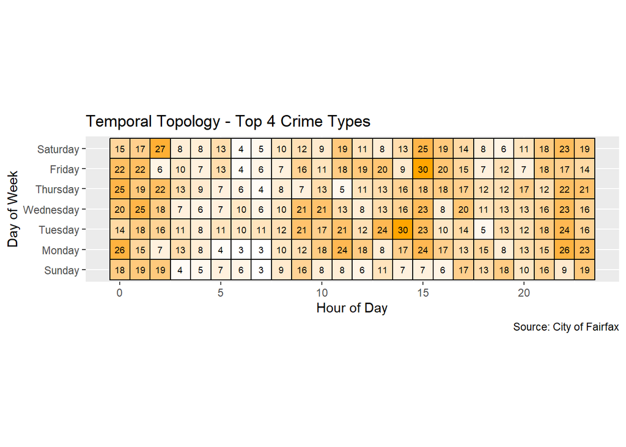

```r
#temp top
ggplot(activity.day.time, aes(hour, dow, fill = count)) +
  geom_tile(color = "black", lwd = .5, linetype = 1) +
  geom_text(aes(label = count), color = "black", size = 2.5) +
  labs(x = "Hour of Day", y = "Day of Week",
       title = "Temporal Topology - Top 4 Crime Types",
       caption = "Source: City of Fairfax") +
  scale_y_discrete(limits = c("Sunday", "Monday", "Tuesday", "Wednesday", "Thursday", "Friday", "Saturday")) +
  scale_fill_gradient(low = "white", high = "orange") +
  theme(legend.position = "none") +
  coord_fixed()
```

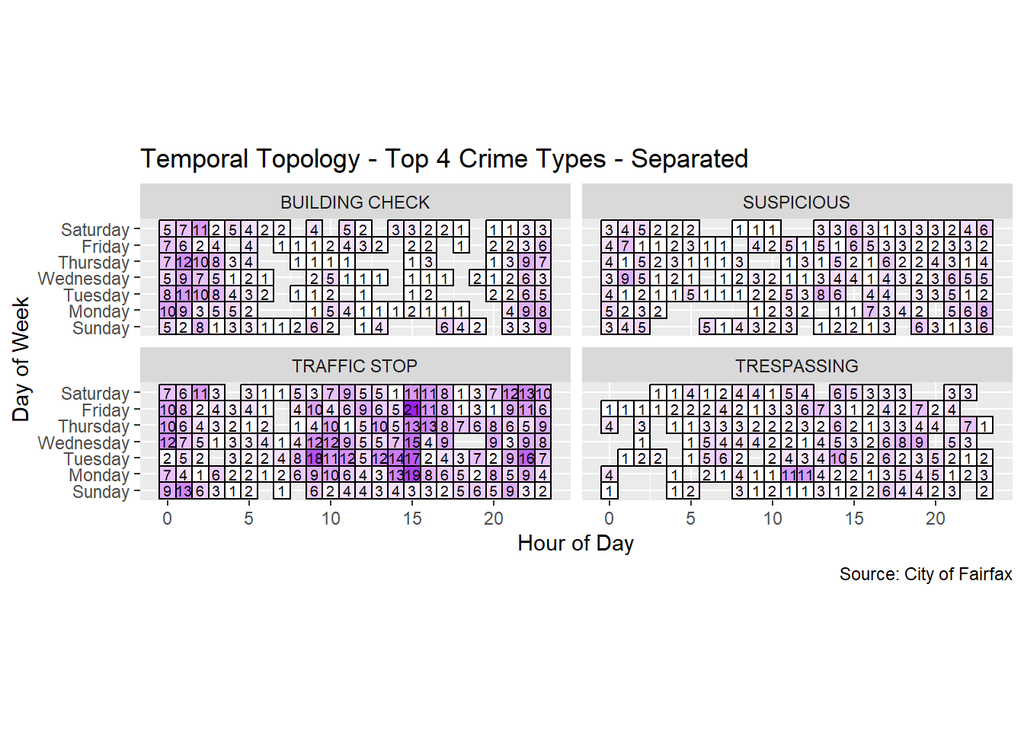

```r
ggplot(activity.type.day.time, aes(hour, dow, fill = count)) +
  geom_tile(color = "black", lwd = .5, linetype = 1) +
  geom_text(aes(label = count), color = "black", size = 2.5) +
  labs(x = "Hour of Day", y = "Day of Week",
       title = "Temporal Topology - Top 4 Crime Types - Separated",
       caption = "Source: City of Fairfax") +
  scale_y_discrete(limits = c("Sunday", "Monday", "Tuesday", "Wednesday", "Thursday", "Friday", "Saturday")) +
  scale_fill_gradient(low = "white", high = "purple") +
  theme(legend.position = "none") +
  coord_fixed() +
  facet_wrap(~ type, nrow = 2)
```

# ANALYTICS

## Summary

I analysed calls for service from Jan 1, 2021 to Apr 30, 2023 near development sites. The starting data gave us 341,026 calls from the start of data collection on Jan 1, 2007. After looking at this data I determined that the four most common calls for service near development projects are Traffic Stops, Building Checks, Suspicious Activity and Trespassing. I decided to only look at these four crime types as they made up the majority of calls. I then filtered by the aforementioned time period and by these four call types which left us with 16,726 calls. From there I only filtered to only include calls that occurred within 75 meters from a development site. This left us with 2,295 data points; this data was only calls within 75 meters of any site and only if they were one of these 4 types of calls for service.

## Behavioral Analysis

As mentioned above these four types made up much of the calls for service around development sites. Combining these four their total calls equaled just over half of all calls for service near development sites. Considering in the original data there were over 50 types of calls, the fact that just 4 call types was able to make up such a large amount of the data was significant enough that I thought it would give us the best analysis of the most regular crimes that occur near sites. Out of these crimes, traffic stops made up the largest piece of data, traffic stops were 43% of these four calls. The other three made up a roughly equal portion of the remainder containing between 18.3-20% for each type.

I would expect little to no change in the types of calls in the area. All of these development sites with the exception of a couple are in major points of the city which means that common calls like traffic stops, building checks, suspicious activity and trespassing are all going to be in high frequency. The only possible change would be if there is redistricting changes to cause the possibility of development project to be in quieter areas or in residential areas of the city. Since this is almost certainly not going to change I do not expect major changes to call types to change near development sites.

## Spacial Analysis

The areas with the most crime activity are also those with the highest concentration of development spots: at the intersection of Chain Bridge and Main St, and near the shopping center at the intersection of Fairfax Blvd and Blenheim Blvd. The next most common spot was at The Shops at Fairfax and the block directly east of it although that spot is much less concentrated. Areas with little or no development spots were: east, central east, northern edge, southern edge and northwest above The Shops at Fairfax. These trends are in line with overall crime numbers that were analysed in the previous spacial analysis project.

## Temporal Analysis

Looking at trends for separate crimes, building checks are most often during 11PM-4AM, traffic stops are most often from 9AM-5PM, and trespassing and suspicious activity are varied with no real hot or cold-spots. Unless major changes to where new development sites occur, I would not expect this to change. If there were a major amount of new development sites I would expect building checks to increase per the data in the spacial analysis. I would suggest having a higher officer count near these development sites on the Midnight shift (2300-700) as the number of development sites have a high correlation with number of building checks and occur mostly in a few hour window. During the other two shifts I would not expect a major increase if the number of development sites were to change since the correlation is less to due with the number of sites and more so to do with where in the city these sites are.